# Cluster project ryan mansfield

Define the problem and perform an Exploratory Data Analysis

- Problem definition, questions to be answered - Data background and contents - Univariate analysis - Bivariate analysis

```python
# I have this installed but I will keep it incase it most be run on a new computer
!pip install yellowbrick
```

```python
# this will help in making the Python code more structured automatically (good coding practice)


# Libraries to help with reading and manipulating data
import numpy as np
import pandas as pd

# Libraries to help with data visualization
import matplotlib.pyplot as plt
import seaborn as sns

sns.set_theme()

# Removes the limit for the number of displayed columns
pd.set_option("display.max_columns", None)
# Sets the limit for the number of displayed rows
pd.set_option("display.max_rows", 200)

# to scale the data using z-score
from sklearn.preprocessing import StandardScaler

# to compute distances
from scipy.spatial.distance import cdist

# to perform k-means clustering and compute silhouette scores
from sklearn.cluster import KMeans
from sklearn.metrics import silhouette_score

# to visualize the elbow curve and silhouette scores
from yellowbrick.cluster import KElbowVisualizer, SilhouetteVisualizer
```

Key questions

- What defines clusters?
- How is one cluster different from anyother?
- What variable(s) is/are most important?
- What buisness insights can we gain

Univariate

```python
# loading the dataset
data = pd.read_csv("Credit_Card_Customer_Data.csv")
```

```python
data.shape #make sure the size is reasonable and get an idea of what it will look like
```

```
(660, 7)
```

```python
data.sample(n=10, random_state=1) # get a sample of the data
```

|  | Sl_No | Customer Key | Avg_Credit_Limit | Total_Credit_Cards | Total_visits_bank | Total_visits_online | Total_calls_made |
| --- | --- | --- | --- | --- | --- | --- | --- |
| 547 | 548 | 38125 | 26000 | 4 | 5 | 2 | 4 |
| 353 | 354 | 94437 | 9000 | 5 | 4 | 1 | 3 |
| 499 | 500 | 65825 | 68000 | 6 | 4 | 2 | 2 |
| 173 | 174 | 38410 | 9000 | 2 | 1 | 5 | 8 |
| 241 | 242 | 81878 | 10000 | 4 | 5 | 1 | 3 |
| 341 | 342 | 70779 | 18000 | 4 | 3 | 2 | 0 |
| 647 | 648 | 79953 | 183000 | 9 | 0 | 9 | 2 |
| 218 | 219 | 28208 | 19000 | 3 | 1 | 5 | 7 |
| 120 | 121 | 16577 | 10000 | 4 | 2 | 4 | 6 |
| 134 | 135 | 31256 | 13000 | 4 | 1 | 5 | 7 |

```python
# copying the data to another variable incase I want to look bacl
df = data.copy()
```

```python
# fixing column names, shouldn't need it but I would like it just to be safe
df.columns = [c.replace(" ", "_") for c in df.columns]
```

```python
# let's look at the structure of the data
df.info()
```

```
<class 'pandas.core.frame.DataFrame'>
RangeIndex: 660 entries, 0 to 659
Data columns (total 7 columns):
 #   Column               Non-Null Count  Dtype
---  ------               --------------  -----
 0   Sl_No                660 non-null    int64
 1   Customer_Key         660 non-null    int64
 2   Avg_Credit_Limit     660 non-null    int64
 3   Total_Credit_Cards   660 non-null    int64
 4   Total_visits_bank    660 non-null    int64
 5   Total_visits_online  660 non-null    int64
 6   Total_calls_made     660 non-null    int64
dtypes: int64(7)
memory usage: 36.2 KB
```

```python
df.drop("Sl_No", axis=1, inplace=True) # this is ameaningless column
```

```python
# let's check for duplicate observations
df.duplicated().sum()
```

```
0
```

```python
df.describe() # get an idea of the spread of the data
```

|  | Customer_Key | Avg_Credit_Limit | Total_Credit_Cards | Total_visits_bank | Total_visits_online | Total_calls_made |
| --- | --- | --- | --- | --- | --- | --- |
| count | 660.000000 | 660.000000 | 660.000000 | 660.000000 | 660.000000 | 660.000000 |
| mean | 55141.443939 | 34574.242424 | 4.706061 | 2.403030 | 2.606061 | 3.583333 |
| std | 25627.772200 | 37625.487804 | 2.167835 | 1.631813 | 2.935724 | 2.865317 |
| min | 11265.000000 | 3000.000000 | 1.000000 | 0.000000 | 0.000000 | 0.000000 |
| 25% | 33825.250000 | 10000.000000 | 3.000000 | 1.000000 | 1.000000 | 1.000000 |
| 50% | 53874.500000 | 18000.000000 | 5.000000 | 2.000000 | 2.000000 | 3.000000 |
| 75% | 77202.500000 | 48000.000000 | 6.000000 | 4.000000 | 4.000000 | 5.000000 |
| max | 99843.000000 | 200000.000000 | 10.000000 | 5.000000 | 15.000000 | 10.000000 |

```python
# function to plot a boxplot and a histogram along the same scale.

#lets look at a boxplot and histogram to see if each vairable is "normal"
def histogram_boxplot(data, feature, figsize=(12, 7), kde=False, bins=None):
    """
    Boxplot and histogram combined

    data: dataframe
    feature: dataframe column
    figsize: size of figure (default (12,7))
    kde: whether to the show density curve (default False)
    bins: number of bins for histogram (default None)
    """
    f2, (ax_box2, ax_hist2) = plt.subplots(
        nrows=2,  # Number of rows of the subplot grid= 2
        sharex=True,  # x-axis will be shared among all subplots
        gridspec_kw={"height_ratios": (0.25, 0.75)},
        figsize=figsize,
    )  # creating the 2 subplots
    sns.boxplot(
        data=data, x=feature, ax=ax_box2, showmeans=True, color="violet"
    )  # boxplot will be created and a star will indicate the mean value of the column
    sns.histplot(
        data=data, x=feature, kde=kde, ax=ax_hist2, bins=bins, palette="winter"
    ) if bins else sns.histplot(
        data=data, x=feature, kde=kde, ax=ax_hist2
    )  # For histogram
    ax_hist2.axvline(
        data[feature].mean(), color="green", linestyle="--"
    )  # Add mean to the histogram
    ax_hist2.axvline(
        data[feature].median(), color="black", linestyle="-"
    )  # Add median to the histogram
```

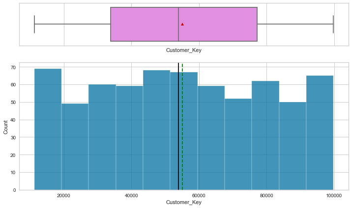

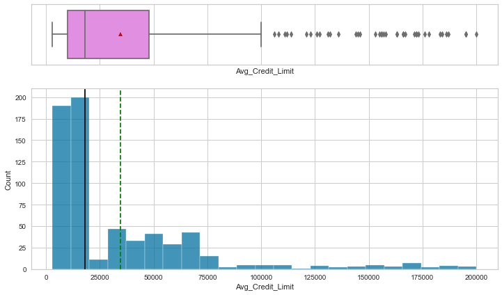

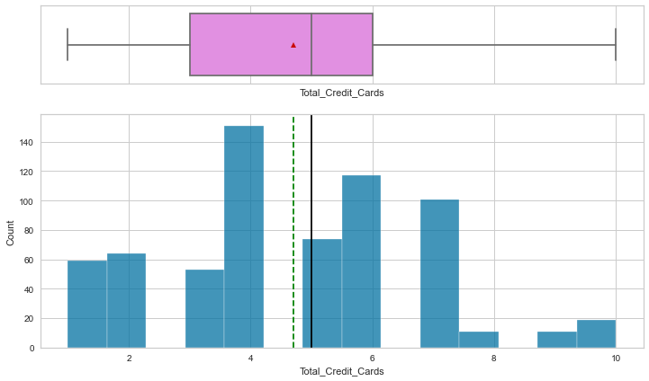

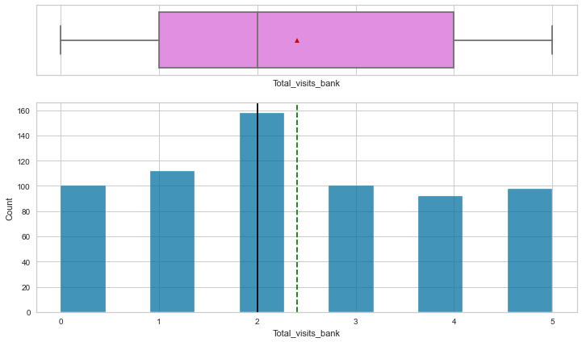

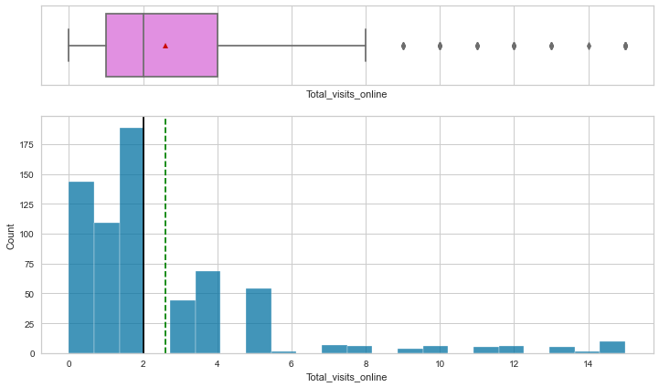

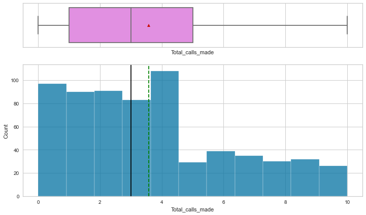

```python
# selecting numerical columns
num_col = df.select_dtypes(include=np.number).columns.tolist()

for item in num_col:
    histogram_boxplot(df, item)
```

Customer key

- seems balanced
- may not be meaningful

Avg Credit limit

- strong right skew

Total credit cards

- slight left skew
- mostly balanced

Total visits bank

- slight right skew

Total visits online

- Right skew

Total calls made

- Slight right skew

```python
a_set = set(df['Customer_Key'])# get one of each of the unique values (i.e if it was 1 1 1 2 we would only get 1 2)
number_of_unique_values = len(a_set) # how many total unique values are there?
number_of_unique_values #print out the number pf unique values
#is customer key worht keeping?
```

```
655
```

there are at most 5 repeated values

```python
df.drop("Customer_Key", axis=1, inplace=True) #not important, remove this colmn
num_col = df.select_dtypes(include=np.number).columns.tolist() # get a list of all the numerical colums
```

Visualization (uni continued)

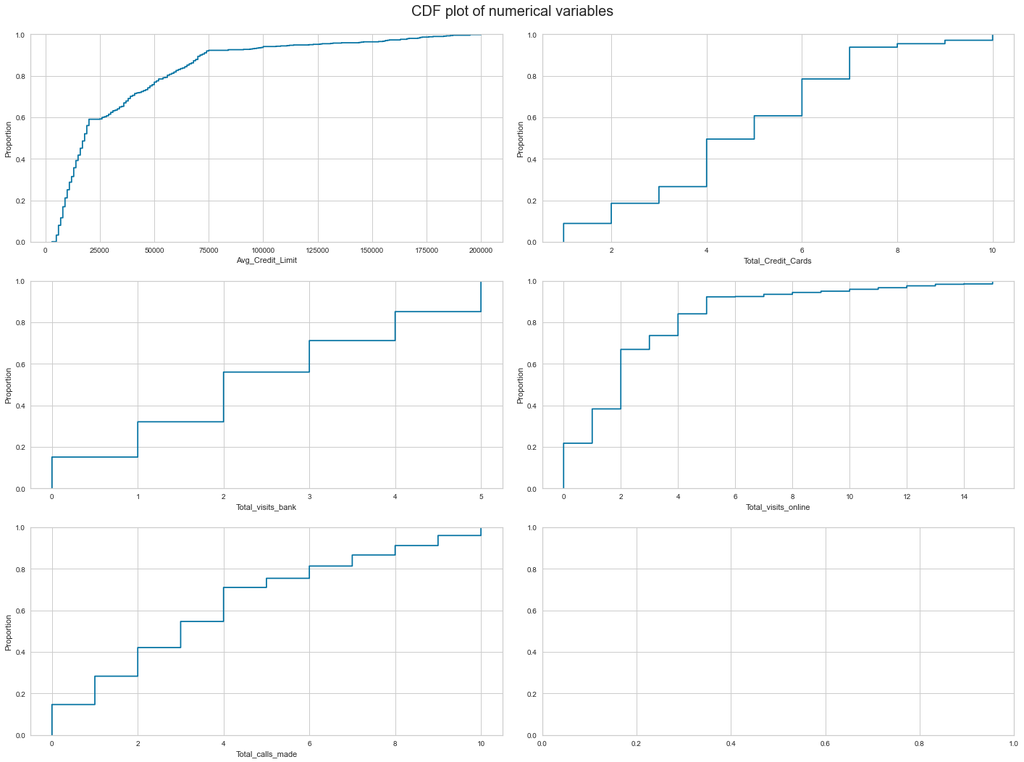

```python
fig, axes = plt.subplots(3, 2, figsize=(20, 15))
fig.suptitle("CDF plot of numerical variables", fontsize=20)
counter = 0
for ii in range(3):
    sns.ecdfplot(ax=axes[ii][0], x=df[num_col[counter]])
    counter = counter + 1
    if counter != 5:
        sns.ecdfplot(ax=axes[ii][1], x=df[num_col[counter]])
        counter = counter + 1
    else:
        pass

fig.tight_layout(pad=2.0)
#create a plot to look at percentalie char,t ie. what percent are at or below a vlaue x
```

observations

Bivariate

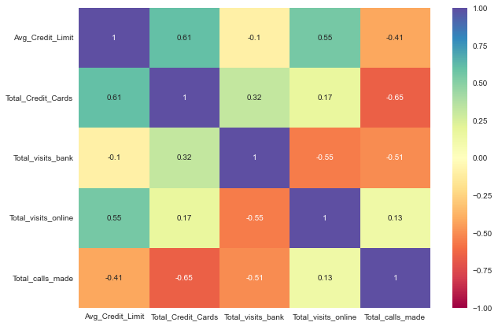

```python
plt.figure(figsize=(10,7))
sns.heatmap(df.corr(),annot=True,vmin=-1,vmax=1,fmt='.2g',cmap="Spectral")# create a heatmap
plt.show()
#the heatmap will show us if any values are strongly correlated
```

Obsevations for high corrleation (above 0.5 or below -0.5)

- None above or near 0.9 or -0.9 (so don't drop any)
- Total credit card and avg credit rating (+0.61) those with higher credit rating have more cards, it may be that they qualify for more or that those with more cards are more likely to pay them off
- Total visits online and avg creidt limit (+0.55) those who visit online have higher credit scores, perhaps using the online featurs makes tracking easier and thus they are more likely to pay off card
- Total calls made and total credit cards (-0.65) those with fewer crtedit cards make more calls, I can't think of a good reason, perhaps they are trying and failing to get another card?
- Total visits bank and total visit online (-0.55) this makes sense, people will likely perfer one of the other and those that can't or don't come in would probably bank online more often
- Total visits bank and total calls made (-0.51) again, this is logical as those who can't come in person may do business in other ways, in this case over the phone

Overvations for hood corrlation (above 0.3 or below -0.3)

- Total visits bank and total credit card (+0.32) those that come in more often may be more likely to sign up for aditional cards
- Total calls made and avg credit limit (-0.41) those with lower credit limits are moe likely to call, perhaps they wish to extent this limit

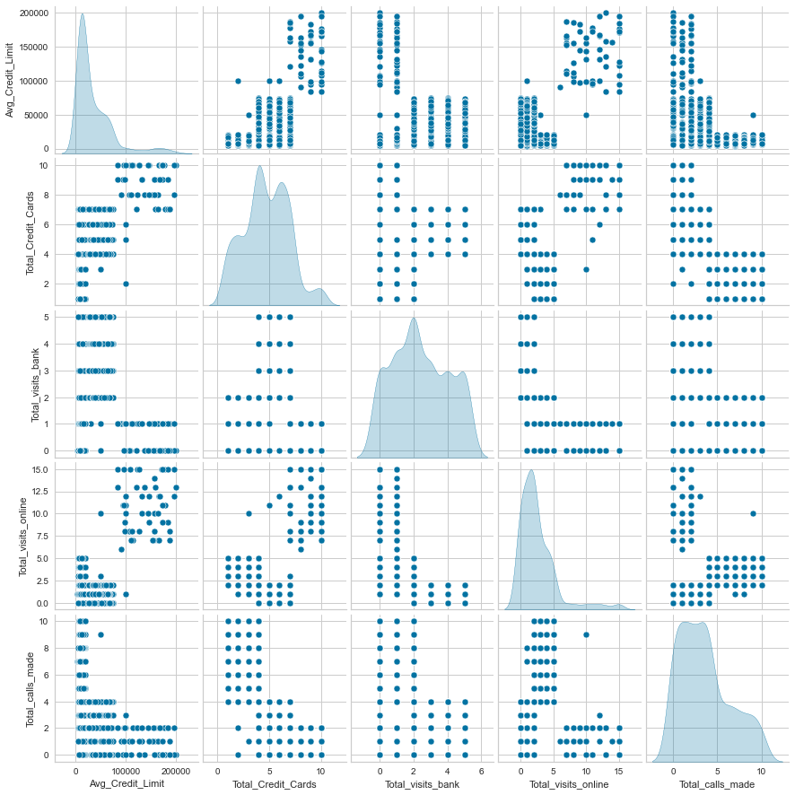

```python
sns.pairplot(data=df[num_col], diag_kind="kde")
plt.show()# get good feel of how each pair of numerical data are related in a grpahical sense
```

Observations

Insights

- Encourage in person visits, this MAY decrease calls, allowing us to hire fewer call center employees, and may encoruage people to sign up for more cards
- Recruit people who would have high credit limit as they may be willing to have additional cards and thus may make us extra maoney, also they may make fewer calls and again reduce the cost of call centers

Data preprocessing Prepare the data for analysis - Feature engineering - Missing value treatment - Outlier treatment - Duplicate observations check

Outliers- best to start here so we don't have to redue z score later

We know we have outliers in two columns, avg credit limt and total visits online and avg creidt limit, even though they seem to not be faulty data, I would recommend treating them if only because kmeans is sensitive

```python
from statistics import stdev

treshold_limit=(df['Avg_Credit_Limit'].median())+2.5*stdev(df['Avg_Credit_Limit'])#create a treshold at mean+2.5*std
for ii in range(len(df['Avg_Credit_Limit'])):
    z=df['Avg_Credit_Limit'][ii]
    if z > treshold_limit: # check if above limit
        df['Avg_Credit_Limit'][ii]=treshold_limit # replace those above with the limit
    else:
        df['Avg_Credit_Limit'][ii]=df['Avg_Credit_Limit'][ii]
```

```python
from statistics import stdev

treshold_vis=(df['Total_visits_online'].median())+2.5*stdev(df['Total_visits_online'])#create the limit at mena+2.5*std
for ii in range(len(df['Total_visits_online'])):
    z=df['Total_visits_online'][ii]
    if z > treshold_limit:#is it above the limit?
        df['Total_visits_online'][ii]=treshold_vis #replace those above with the limit
    else:
        df['Total_visits_online'][ii]=df['Total_visits_online'][ii]
```

```python
# just to remember
num_col
```

```
['Avg_Credit_Limit',
 'Total_Credit_Cards',
 'Total_visits_bank',
 'Total_visits_online',
 'Total_calls_made']
```

```python
# scaling the dataset before clustering with standard (zscore)
scaler = StandardScaler()
subset = df[num_col].copy()
subset_scaled = scaler.fit_transform(subset)
```

```python
# creating a dataframe of the scaled columns
subset_scaled_df = pd.DataFrame(subset_scaled, columns=subset.columns)
```

```python
subset_scaled_df.head(5)#look at what the scaled data looks like
```

|  | Avg_Credit_Limit | Total_Credit_Cards | Total_visits_bank | Total_visits_online | Total_calls_made |
| --- | --- | --- | --- | --- | --- |
| 0 | 2.299548 | -1.249225 | -0.860451 | -0.547490 | -1.251537 |
| 1 | 0.607037 | -0.787585 | -1.473731 | 2.520519 | 1.891859 |
| 2 | 0.607037 | 1.058973 | -0.860451 | 0.134290 | 0.145528 |
| 3 | -0.069968 | 0.135694 | -0.860451 | -0.547490 | 0.145528 |
| 4 | 2.299548 | 0.597334 | -1.473731 | 3.202298 | -0.203739 |

```python
subset_scaled_df.describe()#ensure everything worked
```

|  | Avg_Credit_Limit | Total_Credit_Cards | Total_visits_bank | Total_visits_online | Total_calls_made |
| --- | --- | --- | --- | --- | --- |
| count | 6.600000e+02 | 6.600000e+02 | 6.600000e+02 | 6.600000e+02 | 6.600000e+02 |
| mean | 2.651078e-16 | -4.006223e-15 | 1.157323e-16 | 1.944572e-16 | -7.112156e-16 |
| std | 1.000758e+00 | 1.000758e+00 | 1.000758e+00 | 1.000758e+00 | 1.000758e+00 |
| min | -9.839236e-01 | -1.710864e+00 | -1.473731e+00 | -8.883795e-01 | -1.251537e+00 |
| 25% | -7.469720e-01 | -7.875852e-01 | -8.604506e-01 | -5.474897e-01 | -9.022711e-01 |
| 50% | -4.761703e-01 | 1.356941e-01 | -2.471705e-01 | -2.065999e-01 | -2.037386e-01 |
| 75% | 5.393363e-01 | 5.973337e-01 | 9.793898e-01 | 4.751797e-01 | 4.947938e-01 |
| max | 2.707883e+00 | 2.443892e+00 | 1.592670e+00 | 4.224968e+00 | 2.241125e+00 |

```python
subset_scaled_df.isnull().sum().sort_values(ascending=False)#chekc for missing values
```

```
Avg_Credit_Limit       0
Total_Credit_Cards     0
Total_visits_bank      0
Total_visits_online    0
Total_calls_made       0
dtype: int64
```

No missing values so no missing vale treatment, also no unexpected zeros (for cards and limit)

Applying K-means Clustering

- Apply K-means Clustering - Elbow curve - Silhouette Score - Figure out the appropriate number of clusters

```
Number of Clusters: 1 	Average Distortion: 2.0395805319309317
Number of Clusters: 2 	Average Distortion: 1.4827241521451484
Number of Clusters: 3 	Average Distortion: 1.1755964538861325
Number of Clusters: 4 	Average Distortion: 1.0679161335079486
Number of Clusters: 5 	Average Distortion: 0.9998290428016925
Number of Clusters: 6 	Average Distortion: 0.9449256710570992
Number of Clusters: 7 	Average Distortion: 0.9070395725101147
Number of Clusters: 8 	Average Distortion: 0.8837374636962264
Number of Clusters: 9 	Average Distortion: 0.8610520549354287
```

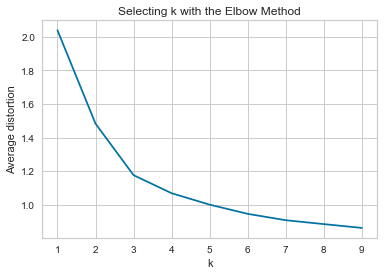

```python
clusters = range(1, 10)
meanDistortions = []
#create the elbow plot to visualize # clsuters needed
for k in clusters:
    model = KMeans(n_clusters=k)
    model.fit(subset_scaled_df)
    prediction = model.predict(subset_scaled_df)
    distortion = (
        sum(
            np.min(cdist(subset_scaled_df, model.cluster_centers_, "euclidean"), axis=1)
        )
        / subset_scaled_df.shape[0]
    )

    meanDistortions.append(distortion)

    print("Number of Clusters:", k, "\tAverage Distortion:", distortion)

plt.plot(clusters, meanDistortions, "bx-")
plt.xlabel("k")
plt.ylabel("Average distortion")
plt.title("Selecting k with the Elbow Method")
plt.show()
```

Based on the elbow 3 or 4 clusters may be best

```
For n_clusters = 2, the silhouette score is 0.4144538086365721)
For n_clusters = 3, the silhouette score is 0.5094254793869142)
For n_clusters = 4, the silhouette score is 0.3744371610680585)
For n_clusters = 5, the silhouette score is 0.34798521193641313)
For n_clusters = 6, the silhouette score is 0.270838199274149)
For n_clusters = 7, the silhouette score is 0.26817914916129487)
For n_clusters = 8, the silhouette score is 0.2576808609462369)
For n_clusters = 9, the silhouette score is 0.2343176437195238)
For n_clusters = 10, the silhouette score is 0.22433435253743197)
```

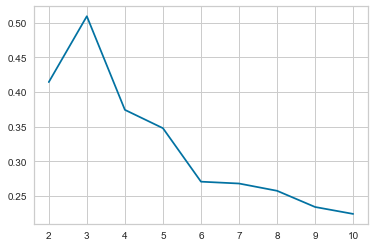

```python
sil_score = []
cluster_list = list(range(2, 11))
#make a plot to show solhouette score for n=1 to 10 clusters (11 not included)
for n_clusters in cluster_list:
    clusterer = KMeans(n_clusters=n_clusters)
    preds = clusterer.fit_predict((subset_scaled_df))
    score = silhouette_score(subset_scaled_df, preds)
    sil_score.append(score)
    print("For n_clusters = {}, the silhouette score is {})".format(n_clusters, score))

plt.plot(cluster_list, sil_score)
plt.show()
```

3 clusters is the clear winner here it is almost 25% better than 2 and 33% than 4, others even worse.

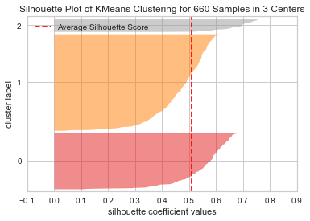

```python
# finding optimal no. of clusters with silhouette coefficients
visualizer = SilhouetteVisualizer(KMeans(3, random_state=1))
visualizer.fit(subset_scaled_df)
visualizer.show()
```

All 3 cluster have atleast some vlaue above average solhouette score and none seem to have negative values so all thre clsuters are good

```python
# let's take 3 as number of clusters
kmeans = KMeans(n_clusters=3, random_state=1)
kmeans.fit(subset_scaled_df)
```

```
KMeans(n_clusters=3, random_state=1)
```

```python
# adding kmeans cluster labels to the original and scaled dataframes

df["K_means_segments"] = kmeans.labels_
subset_scaled_df["K_means_segments"] = kmeans.labels_
```

```python
cluster_profile = df.groupby("K_means_segments").mean() #profile vairbales within eahc cluster
```

```python
cluster_profile["count_in_each_segments"] = (
    df.groupby("K_means_segments")["Avg_Credit_Limit"].count().values
)
```

```python
# let's display cluster profiles
cluster_profile.style.highlight_max(color="lightgreen", axis=0)
```

| K_means_segments | Avg_Credit_Limit | Total_Credit_Cards | Total_visits_bank | Total_visits_online | Total_calls_made | count_in_each_segments |
| --- | --- | --- | --- | --- | --- | --- |
| 0 | 12174.107143 | 2.410714 | 0.933036 | 3.553571 | 6.870536 | 224 |
| 1 | 33782.383420 | 5.515544 | 3.489637 | 0.981865 | 2.000000 | 386 |
| 2 | 107944.100000 | 8.740000 | 0.600000 | 10.900000 | 1.080000 | 50 |

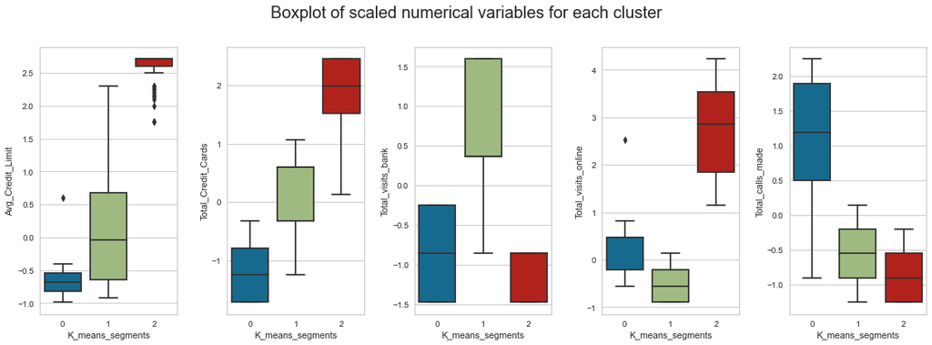

```python
#scaled boxplots of the data for visualizaiton differences in clsuters
fig, axes = plt.subplots(1, 5, figsize=(16, 6))
fig.suptitle("Boxplot of scaled numerical variables for each cluster", fontsize=20)
counter = 0
for ii in range(5):
    sns.boxplot(
        ax=axes[ii],
        y=subset_scaled_df[num_col[counter]],
        x=subset_scaled_df["K_means_segments"],
    )
    counter = counter + 1

fig.tight_layout(pad=2.0)
```

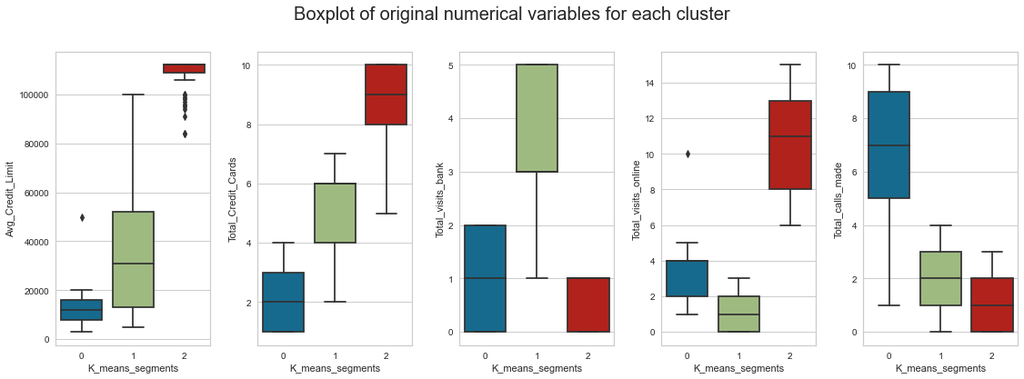

```python
#original scale to see the differences as they relate to actual data
fig, axes = plt.subplots(1, 5, figsize=(16, 6))
fig.suptitle("Boxplot of original numerical variables for each cluster", fontsize=20)
counter = 0
for ii in range(5):
    sns.boxplot(ax=axes[ii], y=df[num_col[counter]], x=df["K_means_segments"])
    counter = counter + 1

fig.tight_layout(pad=2.0)
```

Cluster 0

- This is represent client who may not be as well off
- They have the lowest credit limit and number of cards
- They have the middle ground in terms of bank and online visits
- They call more than the other two groups
- Not as many people as clsuter 1 but more than 2

Cluster 1

- This is the average customer
- More people here than other groups
- They have avergae credit limits and number of credit cards
- They visit the bank the most
- They bank online the least
- They call an avergae amount

Cluster 2

- The high end/rich customers
- Have the highest credit limit and number of cards
- Lowest number of in person visits and calls made
- Highest number of online visits
- Smallest number of people

Insights

Cluster 0

- This is the power customer group, focus on more affordable options
- They call the most so train call center employees in selling some product to them or offer them deals on the phone

Cluster 1

- Average cusotmer, push our standard options
- They prefer in person banking, have fliers/ banners and train teller to pitch products to them

Cluster 2

- Rich cusotmers, push our most high end options
- They like banking online so have online ads and maybe offers online incensentives

Applying Hierarchical Clustering

- Apply Hierarchical Clustering with different linkage methods - Plot dendrograms for each linkage method - Figure out the appropriate number of clusters

```python
# to compute distances
from scipy.spatial.distance import pdist

# to perform hierarchical clustering, compute cophenetic correlation, and create dendrograms
from sklearn.cluster import AgglomerativeClustering
from scipy.cluster.hierarchy import dendrogram, linkage, cophenet
```

```python
# list of distance metrics
distance_metrics = ["euclidean", "chebyshev", "mahalanobis", "cityblock"]

# list of linkage methods
linkage_methods = ["single", "complete", "average", "weighted"]

high_cophenet_corr = 0
high_dm_lm = [0, 0]

for dm in distance_metrics:
    for lm in linkage_methods:
        Z = linkage(subset_scaled_df, metric=dm, method=lm)
        c, coph_dists = cophenet(Z, pdist(subset_scaled_df))
        print(
            "Cophenetic correlation for {} distance and {} linkage is {}.".format(
                dm.capitalize(), lm, c
            )
        )
        if high_cophenet_corr < c:
            high_cophenet_corr = c
            high_dm_lm[0] = dm
            high_dm_lm[1] = lm
```

```
Cophenetic correlation for Euclidean distance and single linkage is 0.8829984821396201.
Cophenetic correlation for Euclidean distance and complete linkage is 0.8644769892299061.
Cophenetic correlation for Euclidean distance and average linkage is 0.9049461048555714.
Cophenetic correlation for Euclidean distance and weighted linkage is 0.8993411003477477.
Cophenetic correlation for Chebyshev distance and single linkage is 0.8859175030109999.
Cophenetic correlation for Chebyshev distance and complete linkage is 0.839113281198533.
Cophenetic correlation for Chebyshev distance and average linkage is 0.9028340755944088.
Cophenetic correlation for Chebyshev distance and weighted linkage is 0.806240289772712.
Cophenetic correlation for Mahalanobis distance and single linkage is 0.8769598813986537.
Cophenetic correlation for Mahalanobis distance and complete linkage is 0.6137165231062094.
Cophenetic correlation for Mahalanobis distance and average linkage is 0.8178912603292822.
Cophenetic correlation for Mahalanobis distance and weighted linkage is 0.7897407318266516.
Cophenetic correlation for Cityblock distance and single linkage is 0.8266034956792553.
Cophenetic correlation for Cityblock distance and complete linkage is 0.8818677538531551.
Cophenetic correlation for Cityblock distance and average linkage is 0.902528067971489.
Cophenetic correlation for Cityblock distance and weighted linkage is 0.8519079277891817.
```

```python
# printing the combination of distance metric and linkage method with the highest cophenetic correlation
print(
    "Highest cophenetic correlation is {}, which is obtained with {} distance and {} linkage.".format(
        high_cophenet_corr, high_dm_lm[0].capitalize(), high_dm_lm[1]
    )
)
```

```
Highest cophenetic correlation is 0.9049461048555714, which is obtained with Euclidean distance and average linkage.
```

Euclidean is best and so I don't think we need to expand on that. Instead I want to see if city block is close

```python
# list of distance metrics
distance_metrics = ["cityblock"]

# list of linkage methods
linkage_methods = ["single", "complete", "average", "weighted"]

high_cophenet_corr2 = 0
high_dm_lm2 = [0, 0]

for dm in distance_metrics:
    for lm in linkage_methods:
        Z = linkage(subset_scaled_df, metric=dm, method=lm)
        c, coph_dists = cophenet(Z, pdist(subset_scaled_df))
        print(
            "Cophenetic correlation for {} distance and {} linkage is {}.".format(
                dm.capitalize(), lm, c
            )
        )
        if high_cophenet_corr2 < c:
            high_cophenet_corr2 = c
            high_dm_lm2[0] = dm
            high_dm_lm2[1] = lm
```

```
Cophenetic correlation for Cityblock distance and single linkage is 0.8266034956792553.
Cophenetic correlation for Cityblock distance and complete linkage is 0.8818677538531551.
Cophenetic correlation for Cityblock distance and average linkage is 0.902528067971489.
Cophenetic correlation for Cityblock distance and weighted linkage is 0.8519079277891817.
```

```python
# printing the combination of distance metric and linkage method with the highest cophenetic correlation
print(
    "Highest cophenetic correlation is {}, which is obtained with {} distance and {} linkage.".format(
        high_cophenet_corr2, high_dm_lm2[0].capitalize(), high_dm_lm2[1]
    )
)
```

```
Highest cophenetic correlation is 0.902528067971489, which is obtained with Cityblock distance and average linkage.
```

Observations

- Best methods is eclidean with average linkage
- If we wanted to do city block, average linkage is the best again

Let's look at dendrograms

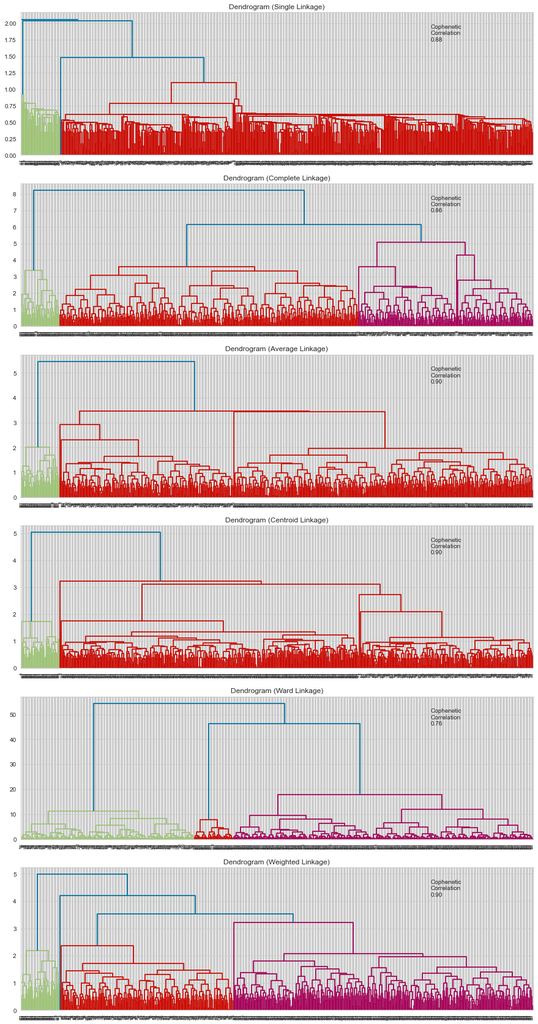

```python
# list of linkage methods
linkage_methods = ["single", "complete", "average", "centroid", "ward", "weighted"]

# lists to save results of cophenetic correlation calculation
compare_cols = ["Linkage", "Cophenetic Coefficient"]
compare = []

# to create a subplot image
fig, axs = plt.subplots(len(linkage_methods), 1, figsize=(15, 30))

# We will enumerate through the list of linkage methods above
# For each linkage method, we will plot the dendrogram and calculate the cophenetic correlation
for i, method in enumerate(linkage_methods):
    Z = linkage(subset_scaled_df, metric="euclidean", method=method)

    dendrogram(Z, ax=axs[i])
    axs[i].set_title(f"Dendrogram ({method.capitalize()} Linkage)")

    coph_corr, coph_dist = cophenet(Z, pdist(subset_scaled_df))
    axs[i].annotate(
        f"Cophenetic\nCorrelation\n{coph_corr:0.2f}",
        (0.80, 0.80),
        xycoords="axes fraction",
    )

    compare.append([method, coph_corr])
```

```python
# let's create a dataframe to compare cophenetic correlations for each linkage method
df_cc = pd.DataFrame(compare, columns=compare_cols)
df_cc
```

|  | Linkage | Cophenetic Coefficient |
| --- | --- | --- |
| 0 | single | 0.882998 |
| 1 | complete | 0.864477 |
| 2 | average | 0.904946 |
| 3 | centroid | 0.902555 |
| 4 | ward | 0.760048 |
| 5 | weighted | 0.899341 |

Average, weighted, and centroid all have high cophenetic coefficients but centroid requires ecludiean distance soo no need for more demdrograms. Let's look at mahalanobis and cityblock for the other two

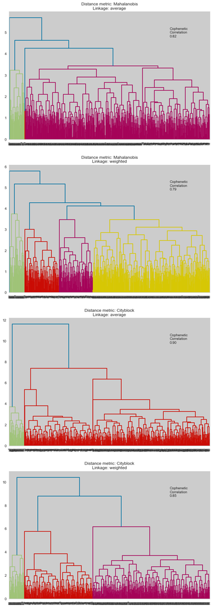

```python
# list of distance metrics
distance_metrics = ["mahalanobis", "cityblock"]

# list of linkage methods
linkage_methods = ["average", "weighted"]

# to create a subplot image
fig, axs = plt.subplots(
    len(distance_metrics) + len(distance_metrics), 1, figsize=(10, 30)
)

i = 0
for dm in distance_metrics:
    for lm in linkage_methods:
        Z = linkage(subset_scaled_df, metric=dm, method=lm)

        dendrogram(Z, ax=axs[i])
        axs[i].set_title("Distance metric: {}\nLinkage: {}".format(dm.capitalize(), lm))

        coph_corr, coph_dist = cophenet(Z, pdist(subset_scaled_df))
        axs[i].annotate(
            f"Cophenetic\nCorrelation\n{coph_corr:0.2f}",
            (0.80, 0.80),
            xycoords="axes fraction",
        )
        i += 1
```

Observations

- Some dendorgrams were bad, some good Ward was the best of those we saw as it's clusters were easier to see
- Ward has 3 clusters

Create ward with 3 clusters

```python
HCmodel = AgglomerativeClustering(n_clusters=3, affinity="euclidean", linkage="ward")
HCmodel.fit(subset_scaled_df)#create the ward clsuters
```

```
AgglomerativeClustering(n_clusters=3)
```

```python
# adding hierarchical cluster labels to the original and scaled dataframes

subset_scaled_df["HC_Clusters"] = HCmodel.labels_
df["HC_Clusters"] = HCmodel.labels_
```

Profile the clusters

```python
cluster_profile = df.groupby("HC_Clusters").mean()#pfoile the clusters for each variable
```

```python
cluster_profile["count_in_each_segments"] = (
    df.groupby("HC_Clusters")["Avg_Credit_Limit"].count().values
)
```

```python
# let's display cluster profiles
cluster_profile.style.highlight_max(color="lightgreen", axis=0)
```

| HC_Clusters | Avg_Credit_Limit | Total_Credit_Cards | Total_visits_bank | Total_visits_online | Total_calls_made | K_means_segments | count_in_each_segments |
| --- | --- | --- | --- | --- | --- | --- | --- |
| 0 | 33782.383420 | 5.515544 | 3.489637 | 0.981865 | 2.000000 | 1.000000 | 386 |
| 1 | 12174.107143 | 2.410714 | 0.933036 | 3.553571 | 6.870536 | 0.000000 | 224 |
| 2 | 107944.100000 | 8.740000 | 0.600000 | 10.900000 | 1.080000 | 2.000000 | 50 |

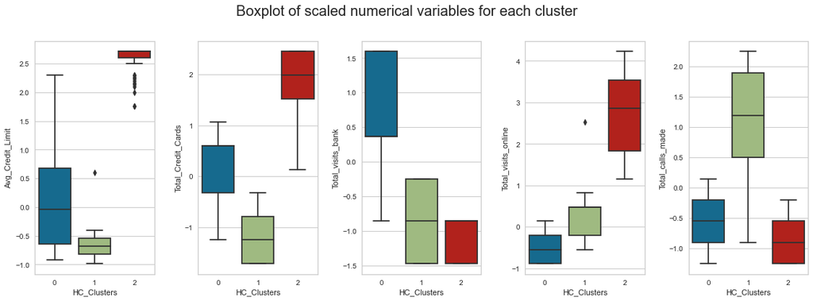

```python
#create scaled boplots to compare the different clsuter
fig, axes = plt.subplots(1, 5, figsize=(16, 6))
fig.suptitle("Boxplot of scaled numerical variables for each cluster", fontsize=20)
counter = 0
for ii in range(5):
    sns.boxplot(
        ax=axes[ii],
        y=subset_scaled_df[num_col[counter]],
        x=subset_scaled_df["HC_Clusters"],
    )
    counter = counter + 1

fig.tight_layout(pad=2.0)
```

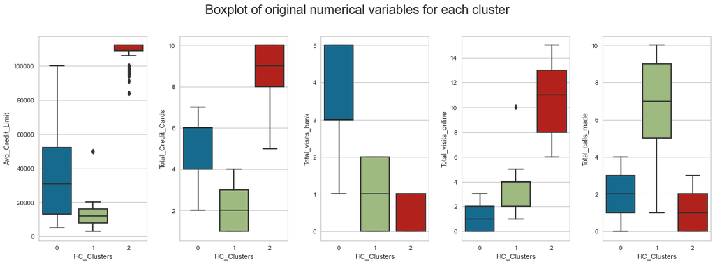

```python
# original scale used here to show relaitonship of the clusters with regards to orignal data
fig, axes = plt.subplots(1, 5, figsize=(16, 6))
fig.suptitle("Boxplot of original numerical variables for each cluster", fontsize=20)
counter = 0
for ii in range(5):
    sns.boxplot(ax=axes[ii], y=df[num_col[counter]], x=df["HC_Clusters"])
    counter = counter + 1

fig.tight_layout(pad=2.0)
```

Cluster 0

- This is the average customer
- More people here than other groups
- They have avergae credit limits and number of credit cards
- They visit the bank the most
- They bank online the least
- They call an avergae amount

Cluster 1

Cluster 2

- The high end/rich customers
- Have the highest credit limit and number of cards
- Lowest number of in person visits and calls made
- Highest number of online visits
- Smallest number of people

Compare clusters from K-means and Hierarchical Clustering and perform cluster profiling

Actionable Insights & Recommendations Conclude with the key takeaways for the business

- What would be your recommendations to the business?

Cluster 0 for K means/ cluster 1 for hierchal

- Run promotions via phone calls, these people are more liekely to call
- Train call centers to deal specifically with issue of lower income people/ those with lower credit limits

Cluster 1 for kmenas/ cluster 0 for hierchal

- Run in person ad campaigns
- Have tellers trained in talking to these people
- Highest number of people here

Cluster 2 for both

- Run online promotions
- Have beenfits for having more than one card with us as they like having more than one card

General

Things to consider

- In time of covid we may not want people coming in to much, maybe do more online promotions to reduce this too
- Encourage people to have 2+ cards with us using online ads
- Basically, I think online would be a good place to start